# RCrawler101-201512

Week 2

Mansun Kuo

2016-01-23

# Outline

- Hello RStudio
- R recap
- Crawler’s toolkits in R
- Save your data
- Case study
- References

# Hello RStudio

[figure not shown]

# Must-known keyboard shortcuts

[All RStudio keyboard shortcuts](https://support.rstudio.com/hc/en-us/articles/200711853-Keyboard-Shortcuts)

| Description | Windows & Linux | Mac |
| --- | --- | --- |
| Show Keyboard Shortcut Reference | Alt+Shift+K | Option+Shift+K |
| Attempt completion / Indent | Tab or Ctrl+Space | Tab or Command+Space |
| Run current line/selection | Ctrl+Enter | Command+Enter |
| Comment/uncomment current line/selection | Ctrl+Shift+C | Command+Shift+C |
| Save active document | Ctrl+S | Command+S |
| Reindent lines | Ctrl+I | Command+I |

# R recap

- How to get help
- Working Environment
- Basic Data Structure
- Function
- if/else, for, tryCache
- magrittr
- [data.table](https://cran.r-project.org/web/packages/data.table/index.html)

# How to get help

- `?`: Access ducument in R console
- `??`: Search the halp system
- google with appropriate keyword. For example:
  - R {package name}
  - R {algorithm name}
- Forum
  - [Taiwan R user Group](http://www.meetup.com/Taiwan-R/)  
    A free R/data analysis user group in Taiwan
  - [Stack Overflow](http://stackoverflow.com/questions/tagged/r)  
    A question and answer site for programmers
  - [PTT R_Language board](https://www.ptt.cc/bbs/R_Language/index.html)  
    A bbs forum for R in Taiwan

# Working Environment

Using `getwd`/`setwd` to get/set your working directory.

```r
wd = getwd()
setwd("img")
getwd()
```

```
## [1] "/home/mansun/github/RCrawler101-201512-2/img"
```

```r
setwd(wd)
getwd()
```

```
## [1] "/home/mansun/github/RCrawler101-201512-2"
```

If you [using Projects](https://support.rstudio.com/hc/en-us/articles/200526207-Using-Projects), RStudio will change working directory for you automatically.

# Basic Data Structure

Vector, Matrix, Array, List and Data frame are the most basic data structure in R. These data structures can be mapped into a table according to:

- dimension
- Homogeneous or Heterogeneous of data type

|  | Homogeneous | Heterogeneous |
| --- | --- | --- |
| 1d | Atomic vector | List |
| 2d | Matrix | Data frame |
| nd | Array |  |

# Vector

Vector is a basic data structure in R. A scalar is a vector of length 1.

```r
v1 <- c(1:10)
v1
```

```
##  [1]  1  2  3  4  5  6  7  8  9 10
```

```r
is.vector(v1)
```

```
## [1] TRUE
```

```r
length(v1)
```

```
## [1] 10
```

```r
s1 <- 2
s1
```

```
## [1] 2
```

```r
is.vector(s1)
```

```
## [1] TRUE
```

```r
length(s1)
```

```
## [1] 1
```

# Type of Vector

Vector can contains several kinds of type. Type describes how the object is stored in memory. Elements in a vector will convert into looser types.

```r
logical_v = c(TRUE, FALSE, T, F)
typeof(logical_v)
```

```
## [1] "logical"
```

```r
int_v <- c(2L, 3L, 4L)
typeof(int_v)
```

```
## [1] "integer"
```

```r
numeric_v <- c(2.5, 3, pi)
typeof(numeric_v)
```

```
## [1] "double"
```

```r
character_v = c("apple", "banana", 1)
typeof(character_v)
```

```
## [1] "character"
```

# Factor

A factor is a vector that can contain only predefined values, and is used to store categorical data. Factors are widely used in various statically function(Ex: Regression, graphics, table) in R.

```r
gender <- c("Male", "Female", "Female", "Male")
gender <- factor(gender)
gender
```

```
## [1] Male   Female Female Male
## Levels: Female Male
```

```r
as.integer(gender)
```

```
## [1] 2 1 1 2
```

```r
as.character(gender)
```

```
## [1] "Male"   "Female" "Female" "Male"
```

# Matrix

Matrix is a 2-dimenstion array. You can have various [matrix operation in R](http://www.statmethods.net/advstats/matrix.html).

```r
x <- matrix(c(2,1,3,2), nrow = 2, ncol = 2)
rownames(x) <- c("a", "b")
colnames(x) <- c("x", "y")
```

# List

Elements in a list can be any kinds type and its length is arbitrary. Function `str` can help you investigate the structure of a nested list.

```r
li <- list(a = 1:10,
           b = c("apple", "banana"))
str(li)
```

```
## List of 2
##  $ a: int [1:10] 1 2 3 4 5 6 7 8 9 10
##  $ b: chr [1:2] "apple" "banana"
```

```r
li2 <- list(li = li,
            c = matrix(1:4, nrow = 2))
str(li2)
```

```
## List of 2
##  $ li:List of 2
##   ..$ a: int [1:10] 1 2 3 4 5 6 7 8 9 10
##   ..$ b: chr [1:2] "apple" "banana"
##  $ c : int [1:2, 1:2] 1 2 3 4
```

# Data Frame

Data frame is a 2-dimension data structure to deal with a table-like heterogeneous data.

```r
df <- data.frame(gender = c("male", "female", "female", "male"),
                 age = c(33, 18, 24, 26))
## Add new column in a data frame
df$city <- c("Taipei", "Taipei", "Hsinchu", "Taichung")
```

```r
df
```

```
##   gender age     city
## 1   male  33   Taipei
## 2 female  18   Taipei
## 3 female  24  Hsinchu
## 4   male  26 Taichung
```

```r
str(df)
```

```
## 'data.frame':    4 obs. of  3 variables:
##  $ gender: Factor w/ 2 levels "female","male": 2 1 1 2
##  $ age   : num  33 18 24 26
##  $ city  : chr  "Taipei" "Taipei" "Hsinchu" "Taichung"
```

# Recap: data structure

All data structures above are objects. They apply different methods and saved as different type internally.

| object | type | class |
| --- | --- | --- |
| c(1, 2.5, 3) | double | numeric |
| c(“male”, “female”, “female”, “male”) | character | character |
| factor(c(“male”, “female”, “female”, “male”)) | integer | factor |
| matrix(1:9, nrow = 3) | integer | matrix |
| list(a = 1:10, b = c(“apple”, “banana”)) | list | list |
| data.frame(a = 1, b = “z”) | list | data.frame |

# Function

*To understand computations in R, two slogans are helpful:*

- *Everything that exists is an object.*
- *Everything that happens is a function call.“*

*— John Chambers*

```r
`+`
```

```
## function (e1, e2)  .Primitive("+")
```

```r
`<-`
```

```
## .Primitive("<-")
```

```r
`[`
```

```
## .Primitive("[")
```

```r
`c`
```

```
## function (..., recursive = FALSE)  .Primitive("c")
```

# Function in R

A typical function in R may look like:

```r
f <- function(arg1, arg2, ...) {
    # Some magic happened
    return()    # return something
}
```

- If you don’t use `return` to specify the return value, the return value will be the last expression inside the function.
- Call by value by default  
  send a copy of a object into a function and the input object won’t change after execution without assignment

# If

The basc structure of conditional execution in R is:

```r
if (an expression returns TRUE or FALSE) {
    # do something
} else if (another expression returns TRUE or FALSE) {
    # do something
} else {
    # do something
}
```

# for

Iterate items in R.

```r
# iterate a character vector
for (i in c("a", "b")) {
    print(i)
}
```

```
## [1] "a"
## [1] "b"
```

```r
# nested loop
m <- matrix(numeric(), nrow = 2, ncol = 2)
for (i in 1:nrow(m)) {
    for (j in 1:ncol(m)) {
        m[i, j] <- i * j
    }
}
m
```

```
##      [,1] [,2]
## [1,]    1    2
## [2,]    2    4
```

# tryCache

tryCache let you deal with error handling in R.

```r
tryCatch({
    result <- expr
}, warning = function(w) {
    # warning handling
}, error = function(e) {
    # error handling
}, finally {
    #  finally
})
```

# magrittr

Pipe argument to right-hand side with `%>%`

- x %>% f is equivalent to f(x)
- x %>% f(y) is equivalent to f(x, y)
- x %>% f %>% g %>% h is equivalent to h(g(f(x)))
- x %>% f(y, .) is equivalent to f(y, x)
- x %>% f(y, z = .) is equivalent to f(y, z = x)

# data.table

- What
  - An enhanced version of data.frames
  - Optimize most heavy works in C
  - Minimize redundant copies
- Why
  - Speed
  - Automatically optimization
  - Total solution for ETL
  - Concise syntax

# data.table: General Form

**DT[i, j, by]**

| R: | i | j | by |
| --- | --- | --- | --- |
| SQL: | where | select/update | group by |

Take **DT**, subset rows using *i*, then calculate *j*, grouped by *by*.

# data.table: a quick overview

- **data.table**: get a data.table
- **fread**: read text file into data.table
- **.**: an abbreviation of list within data.table
- **:=**: add/remove/update a column by reference.
- **by**: to summarize by each group.
- **.SD**: **S**ubset of **D**ata.table. It’s a data table that holds the data for the current group defined using *by*.
- **.SDcols** specifies the columns that returned in .SD.
- **.N**: returns the number of rows in the subset.
- **DT[ … ][ … ][ … ]**: chaining. Avoid intermediate assignment.
- **rbindlist**: same as do.call(“rbind”, l) on data.frames, but faster.
- **copy**: to do a deep copy

# Crawler’s toolkits in R

- [rvest](https://cran.r-project.org/web/packages/rvest/index.html): a web scraper based on httr and xml2
- [httr](https://cran.r-project.org/web/packages/httr/index.html): toolkit of [HTTP methods](http://www.w3schools.com/tags/ref_httpmethods.asp) in R
- [XML](https://cran.r-project.org/web/packages/XML/index.html) & : XML parser
- [xml2](https://cran.r-project.org/web/packages/xml2/index.html): xml parser based on libxml2
- [RCurl](https://cran.r-project.org/web/packages/RCurl/index.html): a wrapper of libcurl

# rvest

A web scraper designed to work with magrittr.

- Create a html document with `read_html()`
- Select parts of a document using css selectors or xpath
  - `html_nodes(doc, css = "<css selector>")`
  - `html_nodes(doc, xpath = "<css selector>")`
- Extract components with
  - `html_name()`: the name of the tag
  - `html_text()`: all text inside the tag
  - `html_attr()`: contents of a single attribute
  - `html_attrs()`: all attributes
  - `html_table`: parse tables into data frames

# A simple HTML document

demo

```r
library(magrittr)
doc = readLines("data/demo.html") %>%
    paste(collapse = "\n")
cat(doc)
```

```
## <!DOCTYPE HTML>
## <html>
##     <body>
##         <div id='title' class='character'>
##             <a class="link" href="http://data-sci.info/r-crawler-101/">Link</a>
##         </div>
##         <div id='summary' class='character'>
##             <span class='title'>Number:</span>
##             <span class='number'>2</span>
##         </div>
##         <div id='table1' class='info'>
##             <table style="width:100%">
##                 <tr>
##                     <th>Name</th>
##                     <th>Gender</th>
##                     <th>Age</th>
##                 </tr>
##                 <tr>
##                     <td>Alice</td>
##                     <td>Female</td>
##                     <td>24</td>
##                 </tr>
##                 <tr>
##                     <td>Jane</td>
##                     <td>Female</td>
##                     <td>26</td>
##                 </tr>
##             </table>
##         </div>
##     </body>
## </html>
```

# Create HTML document

```r
library(rvest)
doc = read_html("data/demo.html")
doc
```

```
## {xml_document}
## <html>
## [1] <body>\n        <div id="title" class="character">\n            <a c ...
```

# Extract with css

```r
doc %>%
    html_nodes(css = ".character") %>%
    html_text
```

```
## [1] "\n            Link\n        "
## [2] "\n            Number:\n            2\n        "
```

```r
doc %>%
    html_nodes(css = "#title > .link") %>%
    html_text
```

```
## [1] "Link"
```

# Extract with xpath

```r
doc %>%
    html_nodes(xpath = "//*[@class='character']") %>%
    html_text
```

```
## [1] "\n            Link\n        "
## [2] "\n            Number:\n            2\n        "
```

```r
doc %>%
    html_nodes(xpath = "//div[@id='title']/a") %>%
    html_text
```

```
## [1] "Link"
```

# Extract name of tag

```r
node = doc %>%
    html_nodes(css = "#summary") %>%
    html_name
node
```

```
## [1] "div"
```

# Extract link

```r
link = doc %>%
    html_nodes(xpath = "/html/body/div[@id='title']/a") %>%
    html_attr("href")
link
```

```
## [1] "http://data-sci.info/r-crawler-101/"
```

# Extract table

```r
students = doc %>%
    html_nodes(xpath = "//table") %>%
    html_table()
students
```

```
## [[1]]
##    Name Gender Age
## 1 Alice Female  24
## 2  Jane Female  26
```

# The secret of URL

```
URL?val1=val1&val2=val2
```

- The query string is sent in the URL of a [GET](http://www.w3schools.com/tags/ref_httpmethods.asp) request
- Non-ASCII character and some preserved characters need to be encoded with [URL Encode](http://www.w3schools.com/tags/ref_urlencode.asp)
- In most situation, you may need to manipulate the query string when you write a crawler

# Url Encoding in R

```r
URLencode(" ")
```

```
## [1] "%20"
```

```r
greeting = "你好嗎我很好"
greeting_enc = URLencode(greeting)
greeting_enc
```

```
## [1] "%E4%BD%A0%E5%A5%BD%E5%97%8E%E6%88%91%E5%BE%88%E5%A5%BD"
```

```r
URLdecode(greeting_enc)
```

```
## [1] "你好嗎我很好"
```

# Concatenate strings / String formatting

```r
paste0("hihi", greeting)
```

```
## [1] "hihi你好嗎我很好"
```

```r
paste0("hihi", greeting, 1:3)
```

```
## [1] "hihi你好嗎我很好1" "hihi你好嗎我很好2" "hihi你好嗎我很好3"
```

```r
paste("hihi", greeting, 1:3, sep = " ", collapse = ",")
```

```
## [1] "hihi 你好嗎我很好 1,hihi 你好嗎我很好 2,hihi 你好嗎我很好 3"
```

```r
sprintf("%s,%s嗎?", "hihi", greeting)
```

```
## [1] "hihi,你好嗎我很好嗎?"
```

# Case study: 東森房屋

- 東森房屋

# Exercise

Try to get some houses’s information in 新北市.

# HTTP request

A valid HTTP request includes four things:

- **URL**: a unique address for a thing
- **Method**:
  - GET: to retrieve a resource
  - POST: to create a new resource
- **Headers**: Meta-information about a request
  - User-Agent
  - Cookie
  - Content-type
  - [List of HTTP header fields](https://en.wikipedia.org/wiki/List_of_HTTP_header_fields)
- **Body**: data to be send to a server

# httr

- Basic Features:
  - HTTP verbs: `GET()`, `POST()`, `HEAD()`…
  - `http_status`: Translate http status code [HTTP status](https://zh.wikipedia.org/wiki/HTTP%E7%8A%B6%E6%80%81%E7%A0%81) code
  - `headers()`: Access response headers
  - `content()`: Retrieve the contents of a request
    - as = “parsed”: detect content type automatically and parse the result
    - as = “text”: return character
    - as = “raw”: return binary
  - `set_cookies()`: set cookles
  - `add_headers()`: add additional headers to a request.

# Take a look at header

Try to use TAB to explore object

```r
library(httr)
url = "http://ecshweb.pchome.com.tw/search/v3.3/all/results?q=sony&page=1&sort=rnk/dc"
res = HEAD(url)
res
```

```
## Response [http://ecshweb.pchome.com.tw/search/v3.3/all/results?q=sony&page=1&sort=rnk/dc]
##   Date: 2016-01-23 11:00
##   Status: 200
##   Content-Type: text/html
## <EMPTY BODY>
```

```r
# HEAD won't return content
res$content
```

```
## raw(0)
```

```r
# see status code
http_status(res)
```

```
## $category
## [1] "success"
##
## $message
## [1] "success: (200) OK"
```

```r
res$status_code
```

```
## [1] 200
```

```r
# extract response headers
head = headers(res)
head$`content-type`
```

```
## [1] "text/html"
```

```r
res$headers$`content-type`
```

```
## [1] "text/html"
```

```r
# whole object
res
```

```
## Response [http://ecshweb.pchome.com.tw/search/v3.3/all/results?q=sony&page=1&sort=rnk/dc]
##   Date: 2016-01-23 11:00
##   Status: 200
##   Content-Type: text/html
## <EMPTY BODY>
```

# GET

Use `GET()` to request data from a specific resource

```r
library(httr)
url = "http://ecshweb.pchome.com.tw/search/v3.3/all/results?q=sony&page=1&sort=rnk/dc"
res = GET(url)
res
```

```
## Response [http://ecshweb.pchome.com.tw/search/v3.3/all/results?q=sony&page=1&sort=rnk/dc]
##   Date: 2016-01-23 11:00
##   Status: 200
##   Content-Type: application/json
##   Size: 9.34 kB
```

```r
res$request
```

```
## <request>
## GET http://ecshweb.pchome.com.tw/search/v3.3/all/results?q=sony&page=1&sort=rnk/dc
## Output: write_memory
## Options:
## * useragent: libcurl/7.35.0 r-curl/0.9.4 httr/1.0.0
## * customrequest: GET
## Headers:
## * Accept: application/json, text/xml, application/xml, */*
```

# Query

You can assign query parameter with `query()`

```r
url2 = "http://ecshweb.pchome.com.tw/search/v3.3/all/results"
res2 = GET(url2, query = list(q="sony", page="1", sort="rnk/dc"))
identical(res$content, res2$content)
```

```
## [1] TRUE
```

# Use string template

```r
library(whisker)

url_template = paste0("http://ecshweb.pchome.com.tw/search/v3.3/all/results?",
                      "q={{q}}&page={{page}}&sort={{sort}}", collapse = "")
url3 = whisker.render(url_template, list(q="sony", page="1", sort="rnk/dc"))
url3
```

```
## [1] "http://ecshweb.pchome.com.tw/search/v3.3/all/results?q=sony&page=1&sort=rnk/dc"
```

```r
res3 = GET(url3)
identical(res$content, res3$content)
```

```
## [1] TRUE
```

# Parse JSON format

Yun can parse [JSON](http://www.w3schools.com/json/) with jsonlite in R

```r
library(jsonlite)
library(magrittr)
res_df = content(res, as = "text") %>%
    fromJSON() %>%
    .$prods     # equivelent to (function(x) {x$prods})
str(res_df)
```

```
## 'data.frame':    20 obs. of  11 variables:
##  $ Id         : chr  "DYAD2O-A9006JDQE" "DYAD2O-A9006SL73" "DYAD27-A90066O9Y" "DPAD06-A90062Y3S" ...
##  $ cateId     : chr  "DYAD2O" "DYAD2O" "DYAD27" "DPAD06" ...
##  $ picS       : chr  "/pic/v1/data/item/201510/D/Y/A/D/2/O/sDYAD2O-A9006JDQE000_560e037b08db2.jpg" "/pic/v1/data/item/201601/D/Y/A/D/2/O/sDYAD2O-A9006SL73000_569c59133420f.jpg" "/pic/v1/data/item/201506/D/Y/A/D/2/7/sDYAD27-A90066O9Y000_5582308468c0b.jpg" "/pic/v1/data/item/201505/D/P/A/D/0/6/sDPA…
##  $ picB       : chr  "/pic/v1/data/item/201601/D/Y/A/D/2/O/DYAD2O-A9006JDQE000_569625b54a236.jpg" "/pic/v1/data/item/201601/D/Y/A/D/2/O/DYAD2O-A9006SL73000_569eebe0d5310.jpg" "/pic/v1/data/item/201506/D/Y/A/D/2/7/DYAD27-A90066O9Y000_5582308467016.jpg" "/pic/v1/data/item/201601/D/P/A/D/0/6/DPAD06-…
##  $ name       : chr  "SONY Xperia Z5" "SONY Xperia Z5(玫瑰石英粉)" "Sony Xperia M4 Aqua dual" "SONY KDL-48W700C 48型 LED液晶電視" ...
##  $ describe   : chr  "▼驚喜價再送保護套SONY Xperia Z5 5.2吋美型防水旗艦機" "▼送原廠行動電源+周杰倫授權背蓋▼SONY Xperia Z5(玫瑰石英粉)" "★送迷你腳架+吊飾★Sony Xperia M4 Aqua " "SONY KDL-48W700C 48型 LED液晶電視 " ...
##  $ price      : int  17500 19900 6850 33900 2290 21490 19900 11900 21000 8880 ...
##  $ author     : chr  "" "" "" "" ...
##  $ brand      : chr  "" "" "" "" ...
##  $ publishDate: chr  "" "" "" "" ...
##  $ isPick     : int  0 0 0 0 0 0 0 0 0 0 ...
```

# Parse with loop

```r
res_list = content(res, as = "parsed")
str(res_list$prods[[1]])
```

```
## List of 11
##  $ Id         : chr "DYAD2O-A9006JDQE"
##  $ cateId     : chr "DYAD2O"
##  $ picS       : chr "/pic/v1/data/item/201510/D/Y/A/D/2/O/sDYAD2O-A9006JDQE000_560e037b08db2.jpg"
##  $ picB       : chr "/pic/v1/data/item/201601/D/Y/A/D/2/O/DYAD2O-A9006JDQE000_569625b54a236.jpg"
##  $ name       : chr "SONY Xperia Z5"
##  $ describe   : chr "▼驚喜價再送保護套SONY Xperia Z5 5.2吋美型防水旗艦機"
##  $ price      : int 17500
##  $ author     : chr ""
##  $ brand      : chr ""
##  $ publishDate: chr ""
##  $ isPick     : int 0
```

```r
res_df2 = data.frame()
for (i in 1:length(res_list$prods)) {
    res_df2 = rbind(res_df2,
                    data.frame(res_list$prods[[i]],
                               stringsAsFactors = FALSE))
}
identical(res_df, res_df2)
```

```
## [1] TRUE
```

# Parse with do.call

```r
res_df3 = data.frame(do.call(rbind, res_list$prods))
identical(res_df, res_df3)
```

```
## [1] FALSE
```

```r
# An ugly data.frame
str(res_df3)
```

[output not shown]

[output cut: 177 more lines]

[output not shown]

# Use with rvest

- Parse data with appropriate encoding
- Bware of System Encoding
- Use `iconv()` and `Sys.setlocale()` in Windows
- Example: Yahoo Stock

# Exercise

[行政院環境保護署環境資源資料開放平台](http://opendata.epa.gov.tw/DevelopZone/Sample/UV/)提供了一系列的RESTful Api供大家取用，請試著把 [紫外線即時監測資料](http://opendata.epa.gov.tw/webapi/api/rest/datastore/355000000I-000004/?format=json)的資料取回來並轉成data.frame

# Answer

紫外線即時監測資料

# Cookies

- A small piece of data sent from a website and stored in the user’s web browser while the user is browsing it
- Someetimes you may need set cookies with `set_cookies` to retreve a request.
  - PTT Gossiping

# POST

- Submits data to be processed to a specified resource
- The query string (name/value pairs) is sent in the HTTP message body

# Example: Guestbook

Guestbook

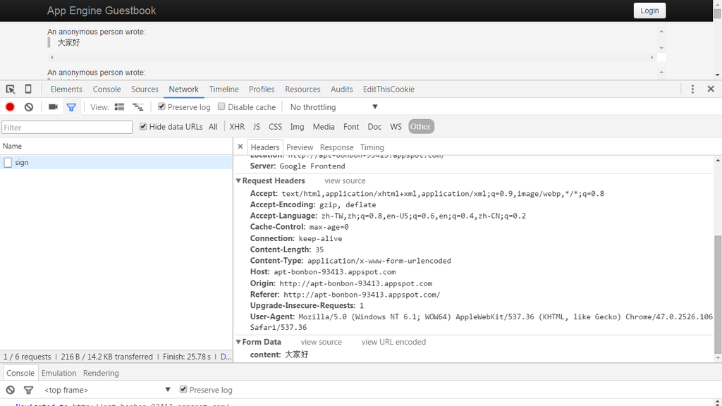

# Exercise: Guestbook

Try to post a message in [App Engine GuestBook](http://apt-bonbon-93413.appspot.com/)

# Set header

Sometime you may need to provide appropriate [HTTP header fields](https://en.wikipedia.org/wiki/List_of_HTTP_header_fields) with `add_headers()` to make a request.

- Starbucks

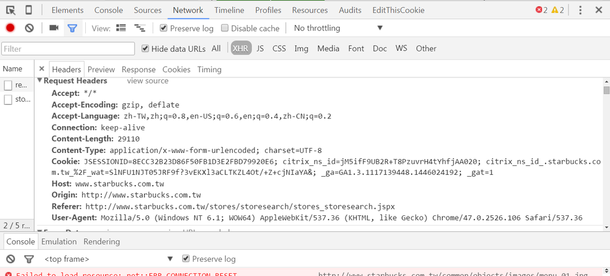

# XML

Parse XML table with `XML::xmlToDataFrame()`

- Seven Eleven

# Save your data

- write.csv: write data.frame as csv file
- download.file: save html, jpeg, etc
- writeBin: write binary object into disk
- RSQLite: SQLite connector in R

# write.csv

```r
library(jsonlite)
library(httr)
url = "http://ecshweb.pchome.com.tw/search/v3.3/all/results?q=sony&page=1&sort=rnk/dc"
res_df = GET(url) %>%
    content(res, as = "text") %>%
    fromJSON() %>%
    .$prods     # equivelent to (function(x) {x$prods})
write.csv(res_df, "data/pchome.csv", row.names = FALSE)
```

# download.file

To download a file from the Internet. download.file takes advantage of internet utilities such as curl or wget and may fail if you don’t have any of these utilities in your system.

```r
dest_dir = "data/download"
dir.create(dest_dir, showWarnings = FALSE, recursive = TRUE)

# Download whole HTML file
download.file("https://www.r-project.org/",
              file.path(dest_dir, "r-project.org.html"))

# Download image
download.file("https://www.r-project.org/Rlogo.png",
              file.path(dest_dir, "Rlogo.png"))

list.files(dest_dir)
```

```
## [1] "Rlogo.png"          "r-project.org.html" "uv.json"
## [4] "uv.txt"
```

# writeBin

To write binary data to your local disk.

```r
r = GET("http://opendata.epa.gov.tw/webapi/api/rest/datastore/355000000I-000004/?format=json")
# Set as = "raw" to prevent any character encoding
bin = content(r, as = "raw")
writeBin(bin, "data/download/uv.json")
```

# Database

- RSQLite: A light-weight database engine interface in R
  - PChome Example
- Other relational database connector in R
  - [RODBC](https://cran.r-project.org/web/packages/RODBC/index.html)
  - [RJDBC](https://cran.r-project.org/web/packages/RJDBC/index.html)
  - [RMySQL](https://cran.r-project.org/web/packages/RMySQL/index.html)
  - …

# Case study

- 東森房屋
- Guestbook
- Yahoo Stock
- 紫外線即時監測資料
- PTT Gossiping
- Starbucks
- Seven Eleven
- PChome
- 公開資訊觀測站
- 中央氣象局觀測資料查詢系統

# References

- rvest
- [httr](https://cran.r-project.org/web/packages/httr/index.html)
- [HTTP Methods](http://www.w3schools.com/tags/ref_httpmethods.asp)
- [An Introduction to APIs](https://zapier.com/learn/apis/)
- [Advanced R](http://adv-r.had.co.nz/)
- data.table
- [RSQLite](https://cran.r-project.org/web/packages/RSQLite/index.html)